# Lane County Jail Analysis

Russell_Corey

March 7, 2023

```
## [1] "data/charges_2023-04-13.csv already exists."
```

# Intro

This report aims to provide insight into the current detained population in the Lane County Jail on April 13, 2023. We will use a Python web scrapper to download the data from the jail’s online inmate search, then format that data into a single table that we will then inspect and generate statistics about the population therein.

Source at https://github.com/russl-corey/Lane_County_Jail

# Data

### Lane County Jail

Inmate data was retrieved from the Lane County Jail’s booking search web portal:

http://inmateinformation.lanecounty.org/Home/BookingSearchQuery

on April 13, 2023.

### Oregon 2020 Census

The 2020 Oregon census data can be found at

https://www.pdx.edu/population-research/census-data-oregon

# Inmates

## Race

Inmate Races

| Race: | count | percentage |
| --- | --- | --- |
| A | 4 | 1.0 |
| B | 28 | 7.1 |
| I | 9 | 2.3 |
| U | 6 | 1.5 |
| W | 345 | 88.0 |

Breakdown of inmates by race. It is probably safe to assume that the ‘W’ category label is probably ‘White’, and similar, ‘A’ and ‘B’ likely could be for ‘Asian’ and ‘Black’ respectively. The other are too obscure to guess at this point.

Also note that as of the 2020 Census, the overall percentage of black people in Lane County is 1.3% and 88.8% for white people. While the inmate population is 7.1% for black inmates and 88% for white inmates. Given this disparity, the odds of a black person in Lane County being an inmate of the jail is 5.5 times more likely than a white community member as of April 13, 2023.

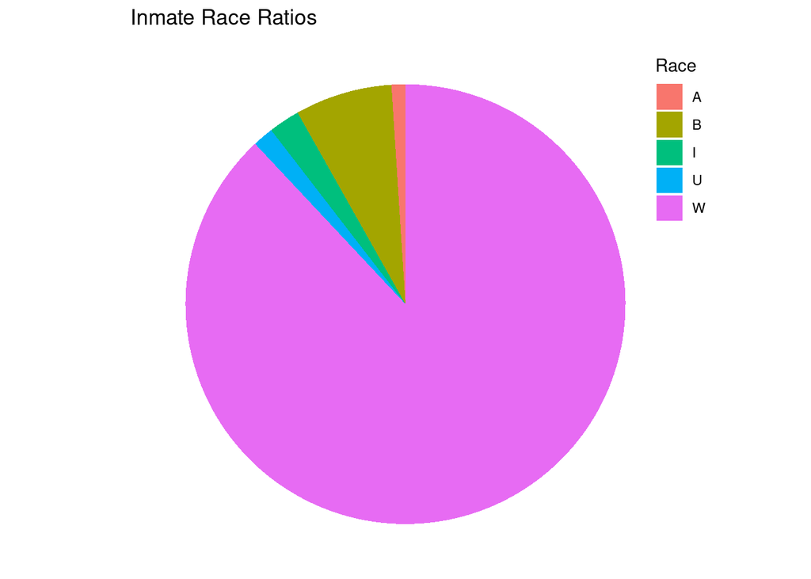

## Bail

An over look of how many inmates are being held without bail and how many have bail requirements. This shows the proportion of inmates that have cash or bond requirements for bail. The people held with bail represent inmates that are being held because of money.

Inmates with/without Bail Requirements

| bail | count | percentage |
| --- | --- | --- |
| Bail | 41 | 11% |
| No Bail | 349 | 89% |

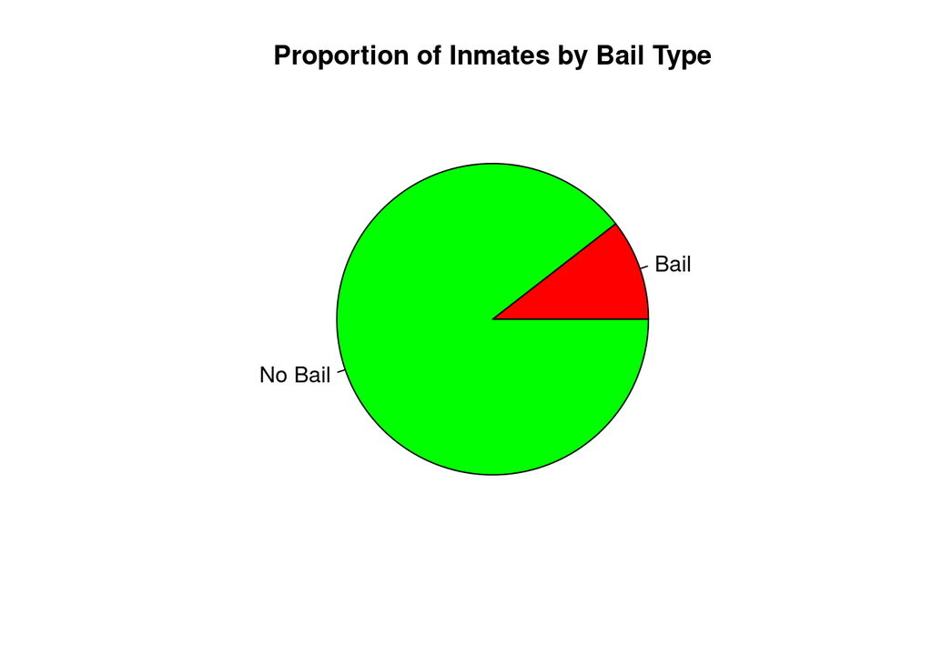

# Charges

## Measure 11

One of the metrics the sheriff has used is concerning inmates awaiting Measure 11 charges. Measure 11 defines minimum mandatory sentences for listed felonies.

> “No pre-trial adults in custody being held on Measure 11 charges have been released due to capacity in nearly 10 years (since July 1, 2013).”

So let us inspect the proportion of inmates that are currently booked on Measure 11 charges.

Inmates with Measure 11 Charges

| Var1 | Freq |
| --- | --- |
| FALSE | 347 |
| TRUE | 45 |

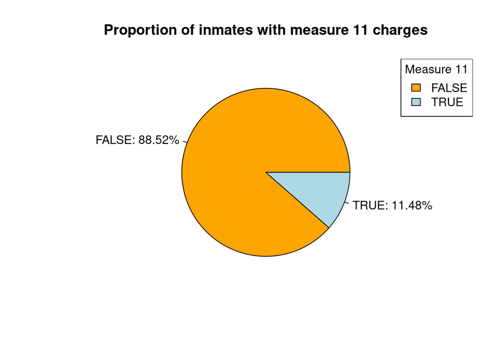

## Violent Felonies

The main concern stated by the Sheriff in regards to the continuation of the jail levy is the release of violent offenders into the community due to capacity releases. So let’s inspect the current inmates booked with at least one violent felony offense. These offenses include all of the Measure 11 violations because all of the Measure 11 charges are violent felonies. Note, the majority of these inmates are also being held pre-trial, and thus presumed innocent.

Inmates with Violent Felony Charges

| Var1 | Freq |
| --- | --- |
| FALSE | 333 |
| TRUE | 59 |

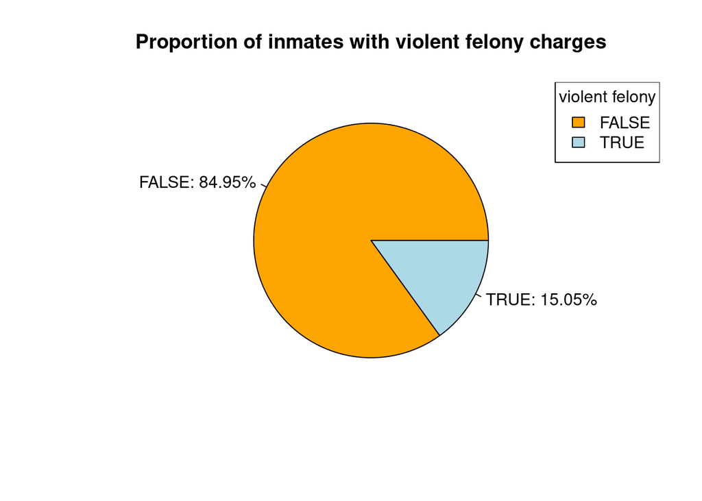

## Top Charges

The majority of inmates are booked for multiple charges. This is a breakdown of the total volume of charges on the books. Keep in mind that there are many more charges than number of inmates.

| Violation: | count |
| --- | --- |
| 813.010 - DRIVE UNDER INFLUENCE INTOX - 1 | 75 |
| 163.160 - ASSAULT 4TH DEG - 1 | 65 |
| 4.807 - CRIMINAL TRESPASS 2 | 51 |
| 806.010 - DRIVING UNINSURED | 35 |
| 811.175 - DRIVING WHILE SUSPENDED VIOLATION | 35 |
| 163.195 - RECKLESSLY ENDANGERING | 32 |
| 166.270 - FELON IN POSSESSION OF WEAPON - 2 | 30 |
| 163.190 - MENACING - 1 | 29 |
| 4.725 - DISORDERLY CONDUCT | 29 |
| 811.140 - RECKLESS DRIVING | 28 |
| 033.045 - CONTEMPT OF COURT | 26 |
| 811.182 - CRIMINAL DRIVING-SUSP/REVOKED - 1 | 26 |
| 144.350 - PAROLE VIOLATION | 25 |
| 4.726 - HARASSMENT | 23 |
| 163.427 - SEX ABUSE 1ST DEG | 22 |
| 166.220 - UNLAWFUL USE OF WEAPON | 21 |
| 164.055 - THEFT 1ST DEG - 1 | 19 |
| 165.800 - IDENTITY THEFT | 19 |
| 161.405 - ATTEMPT TO COMMIT CRIME - 1 | 18 |
| 164.225 - BURGLARY 1ST DEG | 18 |

# Appendix A

source code available at https://github.com/russl-corey/Lane_County_Jail

This program is free software: you can redistribute it and/or modify it under the terms of the GNU General Public License as published by the Free Software Foundation, either version 3 of the License, or (at your option) any later version.

This program is distributed in the hope that it will be useful, but WITHOUT ANY WARRANTY; without even the implied warranty of MERCHANTABILITY or FITNESS FOR A PARTICULAR PURPOSE. See the GNU General Public License for more details. You should have received a copy of the GNU General Public License along with this program. If not, see [<https://www.gnu.org/licenses/>](https://www.gnu.org/licenses/).